# Risk Factor Analysis

## Outcome Variable

**Outcome Variable:** s03rec24

## Predictor Variables

**Intervention Variable:** sex

**Adjustment Set:**

unadjusted

## Stratifying Variables

The analysis was stratified on these variable(s):

- studyid
- country

## Data Summary

| studyid | country | A | n | nA | nAY0 | nAY1 |
| --- | --- | --- | --- | --- | --- | --- |
| ki0047075b-MAL-ED | BANGLADESH | Female | 241 | 126 | 123 | 3 |
| ki0047075b-MAL-ED | BANGLADESH | Male | 241 | 115 | 107 | 8 |
| ki0047075b-MAL-ED | BRAZIL | Female | 220 | 106 | 94 | 12 |
| ki0047075b-MAL-ED | BRAZIL | Male | 220 | 114 | 103 | 11 |
| ki0047075b-MAL-ED | INDIA | Female | 244 | 133 | 123 | 10 |
| ki0047075b-MAL-ED | INDIA | Male | 244 | 111 | 102 | 9 |
| ki0047075b-MAL-ED | NEPAL | Female | 237 | 110 | 105 | 5 |
| ki0047075b-MAL-ED | NEPAL | Male | 237 | 127 | 117 | 10 |
| ki0047075b-MAL-ED | PERU | Female | 276 | 130 | 119 | 11 |
| ki0047075b-MAL-ED | PERU | Male | 276 | 146 | 128 | 18 |
| ki0047075b-MAL-ED | SOUTH AFRICA | Female | 296 | 149 | 134 | 15 |
| ki0047075b-MAL-ED | SOUTH AFRICA | Male | 296 | 147 | 131 | 16 |
| ki0047075b-MAL-ED | TANZANIA, UNITED REPUBLIC OF | Female | 248 | 127 | 125 | 2 |
| ki0047075b-MAL-ED | TANZANIA, UNITED REPUBLIC OF | Male | 248 | 121 | 121 | 0 |
| ki1000108-CMC-V-BCS-2002 | INDIA | Female | 370 | 185 | 170 | 15 |
| ki1000108-CMC-V-BCS-2002 | INDIA | Male | 370 | 185 | 177 | 8 |
| ki1000108-IRC | INDIA | Female | 410 | 185 | 168 | 17 |
| ki1000108-IRC | INDIA | Male | 410 | 225 | 198 | 27 |
| ki1000109-EE | PAKISTAN | Female | 124 | 66 | 66 | 0 |
| ki1000109-EE | PAKISTAN | Male | 124 | 58 | 58 | 0 |
| ki1000109-ResPak | PAKISTAN | Female | 126 | 60 | 60 | 0 |
| ki1000109-ResPak | PAKISTAN | Male | 126 | 66 | 66 | 0 |
| ki1017093b-PROVIDE | BANGLADESH | Female | 686 | 329 | 315 | 14 |
| ki1017093b-PROVIDE | BANGLADESH | Male | 686 | 357 | 342 | 15 |
| ki1066203-TanzaniaChild2 | TANZANIA, UNITED REPUBLIC OF | Female | 2204 | 1118 | 1116 | 2 |
| ki1066203-TanzaniaChild2 | TANZANIA, UNITED REPUBLIC OF | Male | 2204 | 1086 | 1086 | 0 |
| ki1101329-Keneba | GAMBIA | Female | 2431 | 1166 | 1091 | 75 |
| ki1101329-Keneba | GAMBIA | Male | 2431 | 1265 | 1172 | 93 |
| ki1113344-GMS-Nepal | NEPAL | Female | 593 | 283 | 275 | 8 |
| ki1113344-GMS-Nepal | NEPAL | Male | 593 | 310 | 299 | 11 |
| ki1114097-CMIN | BANGLADESH | Female | 259 | 113 | 108 | 5 |
| ki1114097-CMIN | BANGLADESH | Male | 259 | 146 | 138 | 8 |
| ki1114097-CMIN | PERU | Female | 721 | 334 | 334 | 0 |
| ki1114097-CMIN | PERU | Male | 721 | 387 | 385 | 2 |
| ki1114097-CONTENT | PERU | Female | 210 | 105 | 101 | 4 |
| ki1114097-CONTENT | PERU | Male | 210 | 105 | 90 | 15 |

The following strata were considered:

- studyid: ki0047075b-MAL-ED, country: BANGLADESH
- studyid: ki0047075b-MAL-ED, country: BRAZIL
- studyid: ki0047075b-MAL-ED, country: INDIA
- studyid: ki0047075b-MAL-ED, country: NEPAL
- studyid: ki0047075b-MAL-ED, country: PERU
- studyid: ki0047075b-MAL-ED, country: SOUTH AFRICA
- studyid: ki0047075b-MAL-ED, country: TANZANIA, UNITED REPUBLIC OF
- studyid: ki1000108-CMC-V-BCS-2002, country: INDIA
- studyid: ki1000108-IRC, country: INDIA
- studyid: ki1000109-EE, country: PAKISTAN
- studyid: ki1000109-ResPak, country: PAKISTAN
- studyid: ki1017093b-PROVIDE, country: BANGLADESH
- studyid: ki1066203-TanzaniaChild2, country: TANZANIA, UNITED REPUBLIC OF
- studyid: ki1101329-Keneba, country: GAMBIA
- studyid: ki1113344-GMS-Nepal, country: NEPAL
- studyid: ki1114097-CMIN, country: BANGLADESH
- studyid: ki1114097-CMIN, country: PERU
- studyid: ki1114097-CONTENT, country: PERU

### Dropped Strata

Some strata were dropped due to rare outcomes:

- studyid: ki0047075b-MAL-ED, country: BANGLADESH
- studyid: ki0047075b-MAL-ED, country: TANZANIA, UNITED REPUBLIC OF
- studyid: ki1000109-EE, country: PAKISTAN
- studyid: ki1000109-ResPak, country: PAKISTAN
- studyid: ki1066203-TanzaniaChild2, country: TANZANIA, UNITED REPUBLIC OF
- studyid: ki1114097-CMIN, country: PERU
- studyid: ki1114097-CONTENT, country: PERU

## Methods Detail

We’re interested in the causal parameters $E[Y_a]$ for all values of $a \in \mathcal{A}$. These parameters represent the mean outcome if, possibly contrary to fact, we intervened to set all units to have $A=a$. Under the randomization and positivity assumptions, these are identified by the statistical parameters $\psi_a=E_W[E_{Y|A,W}(Y|A=a,W)]$. In addition, we’re interested in the mean of $Y$, $E[Y]$ under no intervention (the observed mean). We will estimate these parameters by using SuperLearner to fit the relevant likelihood factors – $E_{Y|A,W}(Y|A=a,W)$ and $p(A=a|W)$, and then updating our likelihood fit using a joint TMLE.

For unadjusted analyses ($W=\{\}$), initial likelihoods were estimated using Lrnr_glm to estimate the simple $E(Y|A)$ and Lrnr_mean to estimate $p(A)$. For adjusted analyses, a small library containing Lrnr_glmnet, Lrnr_xgboost, and Lrnr_mean was used.

Having estimated these parameters, we will then use the delta method to estimate relative risks and attributable risks relative to a prespecified baseline level of $A$.

# Results Detail

## Results Plots

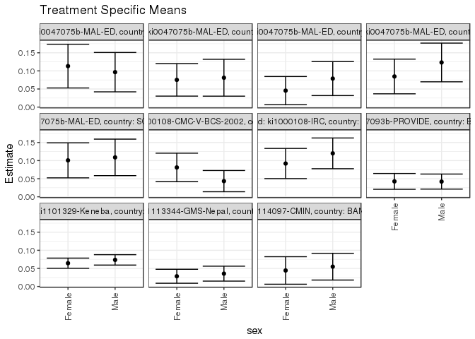

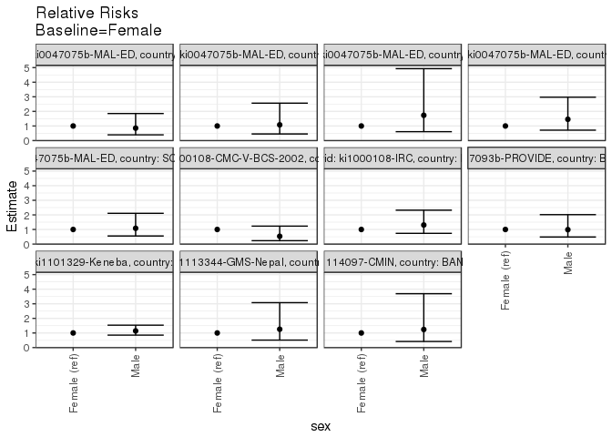

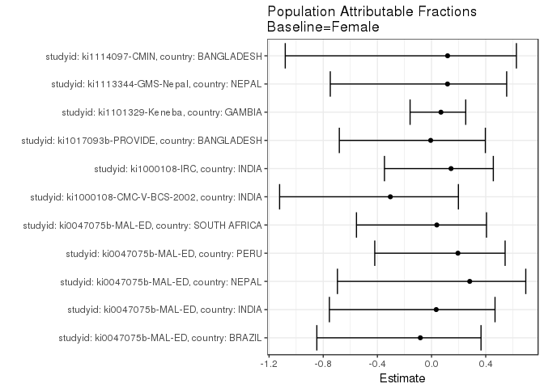

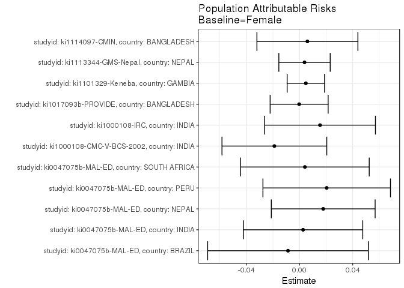

## Results Table

### Parameter: TSM

| studyid | country | intervention_level | baseline_level | estimate | ci_lower | ci_upper |
| --- | --- | --- | --- | --- | --- | --- |
| ki0047075b-MAL-ED | BRAZIL | Female | NA | 0.1132075 | 0.0527524 | 0.1736627 |
| ki0047075b-MAL-ED | BRAZIL | Male | NA | 0.0964912 | 0.0421668 | 0.1508156 |
| ki0047075b-MAL-ED | INDIA | Female | NA | 0.0751880 | 0.0302809 | 0.1200951 |
| ki0047075b-MAL-ED | INDIA | Male | NA | 0.0810811 | 0.0301976 | 0.1319646 |
| ki0047075b-MAL-ED | NEPAL | Female | NA | 0.0454545 | 0.0064463 | 0.0844628 |
| ki0047075b-MAL-ED | NEPAL | Male | NA | 0.0787402 | 0.0317990 | 0.1256813 |
| ki0047075b-MAL-ED | PERU | Female | NA | 0.0846154 | 0.0366872 | 0.1325436 |
| ki0047075b-MAL-ED | PERU | Male | NA | 0.1232877 | 0.0698622 | 0.1767131 |
| ki0047075b-MAL-ED | SOUTH AFRICA | Female | NA | 0.1006711 | 0.0522760 | 0.1490663 |
| ki0047075b-MAL-ED | SOUTH AFRICA | Male | NA | 0.1088435 | 0.0584120 | 0.1592751 |
| ki1000108-CMC-V-BCS-2002 | INDIA | Female | NA | 0.0810811 | 0.0416945 | 0.1204677 |
| ki1000108-CMC-V-BCS-2002 | INDIA | Male | NA | 0.0432432 | 0.0138931 | 0.0725934 |
| ki1000108-IRC | INDIA | Female | NA | 0.0918919 | 0.0502146 | 0.1335692 |
| ki1000108-IRC | INDIA | Male | NA | 0.1200000 | 0.0774873 | 0.1625127 |
| ki1017093b-PROVIDE | BANGLADESH | Female | NA | 0.0425532 | 0.0207264 | 0.0643800 |
| ki1017093b-PROVIDE | BANGLADESH | Male | NA | 0.0420168 | 0.0211901 | 0.0628435 |
| ki1101329-Keneba | GAMBIA | Female | NA | 0.0643225 | 0.0502383 | 0.0784067 |
| ki1101329-Keneba | GAMBIA | Male | NA | 0.0735178 | 0.0591329 | 0.0879027 |
| ki1113344-GMS-Nepal | NEPAL | Female | NA | 0.0282686 | 0.0089424 | 0.0475947 |
| ki1113344-GMS-Nepal | NEPAL | Male | NA | 0.0354839 | 0.0148726 | 0.0560951 |
| ki1114097-CMIN | BANGLADESH | Female | NA | 0.0442478 | 0.0062580 | 0.0822376 |
| ki1114097-CMIN | BANGLADESH | Male | NA | 0.0547945 | 0.0178080 | 0.0917810 |

### Parameter: E(Y)

| studyid | country | intervention_level | baseline_level | estimate | ci_lower | ci_upper |
| --- | --- | --- | --- | --- | --- | --- |
| ki0047075b-MAL-ED | BRAZIL | NA | NA | 0.1045455 | 0.1034392 | 0.1056517 |
| ki0047075b-MAL-ED | INDIA | NA | NA | 0.0778689 | 0.0774999 | 0.0782378 |
| ki0047075b-MAL-ED | NEPAL | NA | NA | 0.0632911 | 0.0611733 | 0.0654090 |
| ki0047075b-MAL-ED | PERU | NA | NA | 0.1050725 | 0.1027910 | 0.1073540 |
| ki0047075b-MAL-ED | SOUTH AFRICA | NA | NA | 0.1047297 | 0.1042635 | 0.1051960 |
| ki1000108-CMC-V-BCS-2002 | INDIA | NA | NA | 0.0621622 | 0.0602318 | 0.0640925 |
| ki1000108-IRC | INDIA | NA | NA | 0.1073171 | 0.1059615 | 0.1086726 |
| ki1017093b-PROVIDE | BANGLADESH | NA | NA | 0.0422741 | 0.0422540 | 0.0422941 |
| ki1101329-Keneba | GAMBIA | NA | NA | 0.0691074 | 0.0689247 | 0.0692900 |
| ki1113344-GMS-Nepal | NEPAL | NA | NA | 0.0320405 | 0.0317502 | 0.0323308 |
| ki1114097-CMIN | BANGLADESH | NA | NA | 0.0501931 | 0.0495548 | 0.0508313 |

### Parameter: RR

| studyid | country | intervention_level | baseline_level | estimate | ci_lower | ci_upper |
| --- | --- | --- | --- | --- | --- | --- |
| ki0047075b-MAL-ED | BRAZIL | Female | Female | 1.0000000 | 1.0000000 | 1.000000 |
| ki0047075b-MAL-ED | BRAZIL | Male | Female | 0.8523392 | 0.3922913 | 1.851895 |
| ki0047075b-MAL-ED | INDIA | Female | Female | 1.0000000 | 1.0000000 | 1.000000 |
| ki0047075b-MAL-ED | INDIA | Male | Female | 1.0783784 | 0.4534410 | 2.564611 |
| ki0047075b-MAL-ED | NEPAL | Female | Female | 1.0000000 | 1.0000000 | 1.000000 |
| ki0047075b-MAL-ED | NEPAL | Male | Female | 1.7322834 | 0.6092737 | 4.925218 |
| ki0047075b-MAL-ED | PERU | Female | Female | 1.0000000 | 1.0000000 | 1.000000 |
| ki0047075b-MAL-ED | PERU | Male | Female | 1.4570361 | 0.7140720 | 2.973025 |
| ki0047075b-MAL-ED | SOUTH AFRICA | Female | Female | 1.0000000 | 1.0000000 | 1.000000 |
| ki0047075b-MAL-ED | SOUTH AFRICA | Male | Female | 1.0811791 | 0.5545404 | 2.107959 |
| ki1000108-CMC-V-BCS-2002 | INDIA | Female | Female | 1.0000000 | 1.0000000 | 1.000000 |
| ki1000108-CMC-V-BCS-2002 | INDIA | Male | Female | 0.5333334 | 0.2314818 | 1.228798 |
| ki1000108-IRC | INDIA | Female | Female | 1.0000000 | 1.0000000 | 1.000000 |
| ki1000108-IRC | INDIA | Male | Female | 1.3058824 | 0.7344500 | 2.321913 |
| ki1017093b-PROVIDE | BANGLADESH | Female | Female | 1.0000000 | 1.0000000 | 1.000000 |
| ki1017093b-PROVIDE | BANGLADESH | Male | Female | 0.9873950 | 0.4838492 | 2.014985 |
| ki1101329-Keneba | GAMBIA | Female | Female | 1.0000000 | 1.0000000 | 1.000000 |
| ki1101329-Keneba | GAMBIA | Male | Female | 1.1429565 | 0.8521178 | 1.533062 |
| ki1113344-GMS-Nepal | NEPAL | Female | Female | 1.0000000 | 1.0000000 | 1.000000 |
| ki1113344-GMS-Nepal | NEPAL | Male | Female | 1.2552419 | 0.5118229 | 3.078472 |
| ki1114097-CMIN | BANGLADESH | Female | Female | 1.0000000 | 1.0000000 | 1.000000 |
| ki1114097-CMIN | BANGLADESH | Male | Female | 1.2383561 | 0.4154651 | 3.691106 |

### Parameter: PAR

| studyid | country | intervention_level | baseline_level | estimate | ci_lower | ci_upper |
| --- | --- | --- | --- | --- | --- | --- |
| ki0047075b-MAL-ED | BRAZIL | Female | NA | -0.0086621 | -0.0691273 | 0.0518032 |
| ki0047075b-MAL-ED | INDIA | Female | NA | 0.0026809 | -0.0422277 | 0.0475895 |
| ki0047075b-MAL-ED | NEPAL | Female | NA | 0.0178366 | -0.0212291 | 0.0569023 |
| ki0047075b-MAL-ED | PERU | Female | NA | 0.0204571 | -0.0275254 | 0.0684395 |
| ki0047075b-MAL-ED | SOUTH AFRICA | Female | NA | 0.0040586 | -0.0443388 | 0.0524560 |
| ki1000108-CMC-V-BCS-2002 | INDIA | Female | NA | -0.0189189 | -0.0583528 | 0.0205149 |
| ki1000108-IRC | INDIA | Female | NA | 0.0154252 | -0.0262742 | 0.0571245 |
| ki1017093b-PROVIDE | BANGLADESH | Female | NA | -0.0002791 | -0.0221060 | 0.0215477 |
| ki1101329-Keneba | GAMBIA | Female | NA | 0.0047849 | -0.0093005 | 0.0188703 |
| ki1113344-GMS-Nepal | NEPAL | Female | NA | 0.0037719 | -0.0155565 | 0.0231003 |
| ki1114097-CMIN | BANGLADESH | Female | NA | 0.0059453 | -0.0320499 | 0.0439405 |

### Parameter: PAF

| studyid | country | intervention_level | baseline_level | estimate | ci_lower | ci_upper |
| --- | --- | --- | --- | --- | --- | --- |
| ki0047075b-MAL-ED | BRAZIL | Female | NA | -0.0828548 | -0.8473016 | 0.3652501 |
| ki0047075b-MAL-ED | INDIA | Female | NA | 0.0344282 | -0.7546131 | 0.4686413 |
| ki0047075b-MAL-ED | NEPAL | Female | NA | 0.2818182 | -0.6952021 | 0.6957383 |
| ki0047075b-MAL-ED | PERU | Female | NA | 0.1946950 | -0.4195019 | 0.5431382 |
| ki0047075b-MAL-ED | SOUTH AFRICA | Female | NA | 0.0387530 | -0.5546052 | 0.4056395 |
| ki1000108-CMC-V-BCS-2002 | INDIA | Female | NA | -0.3043478 | -1.1222196 | 0.1983284 |
| ki1000108-IRC | INDIA | Female | NA | 0.1437346 | -0.3479006 | 0.4560501 |
| ki1017093b-PROVIDE | BANGLADESH | Female | NA | -0.0066031 | -0.6812065 | 0.3973080 |
| ki1101329-Keneba | GAMBIA | Female | NA | 0.0692385 | -0.1586161 | 0.2522831 |
| ki1113344-GMS-Nepal | NEPAL | Female | NA | 0.1177236 | -0.7480032 | 0.5546853 |
| ki1114097-CMIN | BANGLADESH | Female | NA | 0.1184479 | -1.0804684 | 0.6264620 |